# PEC 3

Minería de datos

Autor: Víctor Luque Martín  
Coordinación: Julià Minguillón Alfonso

# Índice de contenidos

1. Preparación del entorno de trabajo
2. Verificación del conjunto de datos a utilizar
3. Enunciado del ejercicio
4. Respuestas
   - Presentación de German Credit Data (Statlog)
   - Análisis descriptivo
     - Variables del Dataset
     - Análisis Básico
     - Análisis Univariado
     - Preparación de los datos
     - Matriz de correlación Global
   - Árbol de decisión
   - Reglas del árbol de decisión
   - Bondad de ajuste
   - Árboles de decisión complementarios
     - Random Forest
     - Gradient Boosting
     - Comparación entre modelos Árbol de Decisión vs Random Forest vs Gradient Boosting
5. Conclusiones Finales
6. Bibliografía

# Preparación del entorno de trabajo

[ Inicio del documento ]

En caso de no tener instalado Python, proponemos descargar python desde su web oficial [python.org](https://www.python.org/downloads/) y trabajar con entornos virtuales haciendo uso de librerías como `venv`, `virtualenv`, `poetry` o `uv`. En este caso haremos uso de `virtualenv` para generar nuestro entorno virtual:

| Descripción | Linux | Windows |
| --- | --- | --- |
| Instalación de virtualenv | `pip install virtualenv` | `pip install virtualenv` |
| Creación del entorno virtual | `virtualenv -p /path/to/python .venv` | `virtualenv -p C:\Path\to\python.exe .venv` |
| Activación del entorno virtual | `source .venv/bin/activate` | `Set-ExecutionPolicy -ExecutionPolicy RemoteSigned -Scope CurrentUser` `.venv/Scripts/activate` |
| Instalación de Jupyter | `pip install notebook` | `pip install notebook` |

No recomendamos el uso del software `Anaconda`, todas las librerías son facilmente instalables desde el repositorio oficial de python [PyPI](https://pypi.org/) además de que en caso de querer realizar una desinstalación de `Anaconda`, este software no se desinstala por completo del equipo, ocupando espacio innecesario y entorpeciendo el rendimiento de tu dispositivo.

Este *notebook* usa varios paquetes Python. Esta es la lista de los más relevantes:

- **NumPy**: contiene una colección de funciones que facilitan el cálculo numérico con matrices.
- **Pandas**: permite trabajar con estructuras de datos tipo *DataFrame*.
- **Scikit-learn**: se trata de una colección de funciones habituales en el mundo de la inteligencia artificial.
- **Matplotlib**: es una librería especializada en la generación de gráficos.
- **Seaborn**: contiene funciones avanzadas para la generación de gráficos estadísticos.
- **Pandera**: librería para validar *DataFrames* de pandas.

Para facilitar el proceso de instalación, proveemos también de los comandos necesarios para ser usados en `pip` una vez activado el entorno virtual:

```
pip install numpy pandas scikit-learn matplotlib seaborn pandera
```

Por defecto, pip instalará la versión más reciente de la librería, pero es posible especificarlo utilizando la siguiente sintáxis `pip install librería==1.2.3`.

```python
# Descomenta la línea de abajo para realizar la instalación de las dependencias
#pip install numpy pandas scikit-learn matplotlib seaborn pandera
```

# Verificación del conjunto de datos a utilizar

[ Inicio del documento ]

Haremos uso de la librería `pandera` para verificar nuestros datos. Esta librería permite definir un esquema de datos y validar que los datos cumplan con ese esquema. Esto es útil para asegurarse de que los datos sean consistentes y estén en el formato esperado antes de realizar análisis o modelado.

```python
import pandera as pa
from pandera import Column, DataFrameSchema, Check
import pandas as pd

schema = DataFrameSchema({
    "checking_balance": Column(pa.String, nullable=False),
    "months_loan_duration": Column(int, Check.ge(0)), # La duración del préstamo no puede ser negativa
    "credit_history": Column(pa.String, nullable=False),
    "purpose": Column(pa.String, nullable=False),
    "amount": Column(int, Check.ge(0)), # La cantidad no puede ser negativa
    "savings_balance": Column(pa.String, nullable=False),
    "employment_length": Column(pa.String, nullable=False),
    "installment_rate": Column(int, Check.ge(0)), # La tasa de instalación no puede ser negativa
    "personal_status": Column(pa.String, nullable=False),
    "other_debtors": Column(pa.String, nullable=False),
    "residence_history": Column(int, Check.ge(0)), # La historia de residencia no puede ser negativa
    "property": Column(pa.String, nullable=False),
    "age": Column(int, Check.ge(0)), # La edad no puede ser negativa
    "housing": Column(pa.String, nullable=False),
    "job": Column(pa.String, nullable=False),
    "dependents": Column(int, Check.ge(0)), # Los dependientes no pueden ser negativos
    "telephone": Column(pa.String, nullable=False),
    "foreign_worker": Column(pa.String, nullable=False)
})
schema.validate(pd.read_csv("credit.csv")) # Cambia el nombre del archivo si es necesario
print("El archivo credit.csv cumple con el esquema definido.")
```

```
El archivo credit.csv cumple con el esquema definido.
```

# Enunciado del ejercicio

[ inicio del documento ]

Para el conjunto de datos German Credit, los alumnos deben completar aquí la solución a la PEC3 que consiste de los siguientes apartados. El formato de entrega es como en las anteriores PECs: **usernameestudiant-PECn.html** (o PDF/HTML) y el código **.Rmd**. Se debe entregar la PEC en el buzón de entregas del aula, como en las anteriores PECs.

**(Obligatorio)** Se debe realizar un breve informe (Html) donde se respondan a las preguntas concretas, mostrando en primer lugar el código utilizado, luego los resultados y posteriormente los comentarios que se consideren pertinentes para cada apartado.

## Análisis descriptivo (20%)

Realizar un primer análisis descriptivo, preparando y acondicionando correctamente los datos. Sucesivamente realizar un análisis de correlaciones de las variables. Es importante en este apartado entender bien los datos antes de seguir con los análisis posteriores. Lista todo lo que te haya sorprendido de los datos.

Evaluación:

- 10% Hay un estudio sobre los datos de los que se parte, las variables que componen los datos. Los datos son preparados correctamente.
- 10% Se realiza un análisis descriptivo univariante (o análisis de relevancia) de algunas variables una vez se han tratado vs el target a nivel gráfico, comentando las que aparentemente son más interesantes. Análogamente se realiza un análisis de correlaciones.

## Árbol de decisión (20%)

Realizar un primer árbol de decisión. Puedes decidir utilizar todas las variables o, de forma justificada, quitar alguna para el ajuste del modelo.

Evaluación:

- 10% Se aplica un árbol de decisión de forma correcta.
- 10% Se obtiene una estimación del error, mostrando gráficamente el árbol obtenido. La visualización debe ser comprensible y adecuada al problema a resolver.

## Reglas del árbol de decisión (15%)

Con el árbol obtenido, realiza una breve explicación de las reglas obtenidas así como de todos los puntos que te parezcan interesantes. Un elemento a considerar es, por ejemplo, cuantas observaciones caen dentro de cada regla.

Evaluación:

- 15% Se explican las reglas que se obtienen en términos concretos del problema a resolver.

## Bondad de ajuste (10%)

Una vez tengas un modelo válido, procede a realizar un análisis de la bondad de ajuste sobre el conjunto de test y matriz de confusión. ¿Te parece un modelo suficientemente bueno como para utilizarlo? Justifica tu respuesta considerando todos los posibles tipos de error.

Evaluación:

- 5% Se usa el modelo para predecir con muestras no usadas en el entrenamiento (holdout) y se obtiene una estimación del error.
- 5% En base a la matriz de confusión, se comentan los tipos de errores y se valora de forma adecuada la capacidad predictiva del algoritmo.

## Árboles de decisión complementarios (10%)

Con un enfoque parecido a los puntos anteriores y considerando las mismas variables, enriquece el ejercicio mediante el ajuste de modelos de árbol de decisión complementarios. Por ejemplo, crear el modelo con todos los datos y validación cruzada; probar el boosting o variar el pruning, etc. ¿Es el nuevo enfoque mejor que el original? Justifica la respuesta.

Evaluación:

- 10% Se prueba otro modelo de árbol o variantes diferentes del C50 y se comparan los resultados obtenidos, valorando si son mejores. Se recomienda experimentar usando un Random Forest (librería de R *randomForest* (https://cran.r-project.org/web/packages/randomForest/randomForest.pdf)).

## Conclusiones finales (25%)

Haz un resumen de las principales conclusiones de todos los análisis y modelos realizados.

Evaluación:

- 10% Con los resultados obtenidos anteriormente, se presentan unas conclusiones contextualizadas donde se expone un resumen de los diferentes modelos utilizados (al menos 3) así como el conocimiento adquirido tras el trabajo realizado y los descubrimientos más importantes realizados en el conjunto de datos.
- 10% Utiliza métricas de explicabilidad como las comentadas en el ejemplo para obtener conclusiones de los datos.
- 5% Se presenta el código y es fácilmente reproducible.

# Respuestas

## Presentación de German Credit Data (Statlog)

[ inicio del documento ]

Este conjunto de datos clasifica a las personas según un conjunto de atributos como de alto o bajo riesgo crediticio. El objetivo es predecir si una persona es un buen o mal pagador, basándose en su historial crediticio y otros factores. Este conjunto de datos se utiliza comúnmente para evaluar la capacidad de un modelo para clasificar correctamente a los prestatarios en función de su riesgo crediticio.

Podemos encontrar el dataset **original** en el UCI Repository: [Statlog (German Credit Data)](https://archive.ics.uci.edu/dataset/144/statlog+german+credit+data).

Nosotros haremos uso del dataset proporcionado por la UOC `credit.csv` a través del enunciado de la práctica.

```python
import pandas as pd

df = pd.read_csv("credit.csv")
df
```

|  | checking_balance | months_loan_duration | credit_history | purpose | amount | savings_balance | employment_length | installment_rate | personal_status | other_debtors | ... | property | age | installment_plan | housing | existing_credits | default | dependents | telephone | foreign_worker | job |
| --- | --- | --- | --- | --- | --- | --- | --- | --- | --- | --- | --- | --- | --- | --- | --- | --- | --- | --- | --- | --- | --- |
| 0 | < 0 DM | 6 | critical | radio/tv | 1169 | unknown | > 7 yrs | 4 | single male | none | ... | real estate | 67 | none | own | 2 | 1 | 1 | yes | yes | skilled employee |
| 1 | 1 - 200 DM | 48 | repaid | radio/tv | 5951 | < 100 DM | 1 - 4 yrs | 2 | female | none | ... | real estate | 22 | none | own | 1 | 2 | 1 | none | yes | skilled employee |
| 2 | unknown | 12 | critical | education | 2096 | < 100 DM | 4 - 7 yrs | 2 | single male | none | ... | real estate | 49 | none | own | 1 | 1 | 2 | none | yes | unskilled resident |
| 3 | < 0 DM | 42 | repaid | furniture | 7882 | < 100 DM | 4 - 7 yrs | 2 | single male | guarantor | ... | building society savings | 45 | none | for free | 1 | 1 | 2 | none | yes | skilled employee |
| 4 | < 0 DM | 24 | delayed | car (new) | 4870 | < 100 DM | 1 - 4 yrs | 3 | single male | none | ... | unknown/none | 53 | none | for free | 2 | 2 | 2 | none | yes | skilled employee |
| ... | ... | ... | ... | ... | ... | ... | ... | ... | ... | ... | ... | ... | ... | ... | ... | ... | ... | ... | ... | ... | ... |
| 995 | unknown | 12 | repaid | furniture | 1736 | < 100 DM | 4 - 7 yrs | 3 | female | none | ... | real estate | 31 | none | own | 1 | 1 | 1 | none | yes | unskilled resident |
| 996 | < 0 DM | 30 | repaid | car (used) | 3857 | < 100 DM | 1 - 4 yrs | 4 | divorced male | none | ... | building society savings | 40 | none | own | 1 | 1 | 1 | yes | yes | mangement self-employed |
| 997 | unknown | 12 | repaid | radio/tv | 804 | < 100 DM | > 7 yrs | 4 | single male | none | ... | other | 38 | none | own | 1 | 1 | 1 | none | yes | skilled employee |
| 998 | < 0 DM | 45 | repaid | radio/tv | 1845 | < 100 DM | 1 - 4 yrs | 4 | single male | none | ... | unknown/none | 23 | none | for free | 1 | 2 | 1 | yes | yes | skilled employee |
| 999 | 1 - 200 DM | 45 | critical | car (used) | 4576 | 101 - 500 DM | unemployed | 3 | single male | none | ... | other | 27 | none | own | 1 | 1 | 1 | none | yes | skilled employee |

1000 rows × 21 columns

Por norma general la variable objetivo es la última columna del dataset, en este caso `default` no se encuentra en la última columna. Para evitar confusiones la moveremos a la última posición del dataset. De esta forma, el dataset tendrá la siguiente estructura:

```python
default = df.default
df.drop(columns=["default"], inplace=True) # Eliminamos la columna default del DataFrame
df['default'] = default # Añadimos la columna default al final del DataFrame
df.head()
```

|  | checking_balance | months_loan_duration | credit_history | purpose | amount | savings_balance | employment_length | installment_rate | personal_status | other_debtors | ... | property | age | installment_plan | housing | existing_credits | dependents | telephone | foreign_worker | job | default |
| --- | --- | --- | --- | --- | --- | --- | --- | --- | --- | --- | --- | --- | --- | --- | --- | --- | --- | --- | --- | --- | --- |
| 0 | < 0 DM | 6 | critical | radio/tv | 1169 | unknown | > 7 yrs | 4 | single male | none | ... | real estate | 67 | none | own | 2 | 1 | yes | yes | skilled employee | 1 |
| 1 | 1 - 200 DM | 48 | repaid | radio/tv | 5951 | < 100 DM | 1 - 4 yrs | 2 | female | none | ... | real estate | 22 | none | own | 1 | 1 | none | yes | skilled employee | 2 |
| 2 | unknown | 12 | critical | education | 2096 | < 100 DM | 4 - 7 yrs | 2 | single male | none | ... | real estate | 49 | none | own | 1 | 2 | none | yes | unskilled resident | 1 |
| 3 | < 0 DM | 42 | repaid | furniture | 7882 | < 100 DM | 4 - 7 yrs | 2 | single male | guarantor | ... | building society savings | 45 | none | for free | 1 | 2 | none | yes | skilled employee | 1 |
| 4 | < 0 DM | 24 | delayed | car (new) | 4870 | < 100 DM | 1 - 4 yrs | 3 | single male | none | ... | unknown/none | 53 | none | for free | 2 | 2 | none | yes | skilled employee | 2 |

5 rows × 21 columns

## Análisis descriptivo

[ inicio del documento ]

Primeramente debemos describir los atributos del dataset, así como la variable objetivo.

### Variables del Dataset

#### Variable objetivo (o dependiente):

- `default`: Si se trata de un buen (1) o mal (2) pagador (categórico)

```python
X, y = df.drop(columns=["default"]), df["default"]
```

### Análisis Básico

[ inicio del documento ]

Observemos de forma genérica la información de las variables del dataset

```python
X.info(), X.describe()
```

```
<class 'pandas.core.frame.DataFrame'>
RangeIndex: 1000 entries, 0 to 999
Data columns (total 20 columns):
 #   Column                Non-Null Count  Dtype
---  ------                --------------  -----
 0   checking_balance      1000 non-null   object
 1   months_loan_duration  1000 non-null   int64
 2   credit_history        1000 non-null   object
 3   purpose               1000 non-null   object
 4   amount                1000 non-null   int64
 5   savings_balance       1000 non-null   object
 6   employment_length     1000 non-null   object
 7   installment_rate      1000 non-null   int64
 8   personal_status       1000 non-null   object
 9   other_debtors         1000 non-null   object
 10  residence_history     1000 non-null   int64
 11  property              1000 non-null   object
 12  age                   1000 non-null   int64
 13  installment_plan      1000 non-null   object
 14  housing               1000 non-null   object
 15  existing_credits      1000 non-null   int64
 16  dependents            1000 non-null   int64
 17  telephone             1000 non-null   object
 18  foreign_worker        1000 non-null   object
 19  job                   1000 non-null   object
dtypes: int64(7), object(13)
memory usage: 156.4+ KB
```

```
(None,
        months_loan_duration        amount  installment_rate  \
 count           1000.000000   1000.000000       1000.000000
 mean              20.903000   3271.258000          2.973000
 std               12.058814   2822.736876          1.118715
 min                4.000000    250.000000          1.000000
 25%               12.000000   1365.500000          2.000000
 50%               18.000000   2319.500000          3.000000
 75%               24.000000   3972.250000          4.000000
 max               72.000000  18424.000000          4.000000

        residence_history          age  existing_credits   dependents
 count        1000.000000  1000.000000       1000.000000  1000.000000
 mean            2.845000    35.546000          1.407000     1.155000
 std             1.103718    11.375469          0.577654     0.362086
 min             1.000000    19.000000          1.000000     1.000000
 25%             2.000000    27.000000          1.000000     1.000000
 50%             3.000000    33.000000          1.000000     1.000000
 75%             4.000000    42.000000          2.000000     1.000000
 max             4.000000    75.000000          4.000000     2.000000  )
```

Comprobamos si existen duplicados

```python
print(f"Hay un total de {int(X.duplicated().sum())} duplicados")
```

```
Hay un total de 0 duplicados
```

```python
# Función de ayuda para añadir etiquetas de número y porcentaje a los gráficos

def add_number_and_percentage_annotation(ax, total, type = 'count'):
    for p in ax.patches:
        if height := p.get_height(): # Walrus operador (:=): Asigna y devuelve el valor de h
            x = p.get_x()
            width = p.get_width()
            bottom = p.get_y()
            center_x = x + width / 2
            per = (height / total) * 100
            if type == 'proportion' and height > .05:
                ax.text(
                    center_x,
                    bottom + 0.01,  # Pegado al inicio del segmento
                    f"{height:.2f}",
                    ha='center',
                    va='bottom',
                    fontsize=12,
                    color='black'
                )
            else:
                ax.annotate(
                    f'{height:.0f} ({per:.1f}%)',
                    (p.get_x() + p.get_width() / 2., height),
                    ha='center', va='center',
                    fontsize=12, color='black',
                    xytext=(0, 5), textcoords='offset points'
                )
```

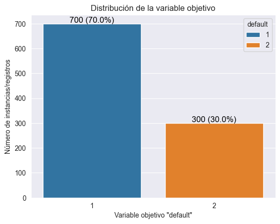

```python
import seaborn as sns
import matplotlib.pyplot as plt

sns.set_style("darkgrid")
ax = sns.countplot(df, x='default', hue='default', palette='tab10')
total = df.shape[0]
add_number_and_percentage_annotation(ax, total)


plt.title('Distribución de la variable objetivo')
plt.xlabel('Variable objetivo "default"')
plt.ylabel("Número de instancias/registros")
plt.show()
```

**Conclusiones**

- El dataset contiene 1000 observaciones y 20 variables.
- No encontramos valores nulos en el dataset.
- No encontramos duplicados en el dataset.
- La variable objetivo `default` está desbalanceada, ya que el 70% de los datos son buenos pagadores y el 30% son malos pagadores. Esto puede afectar la capacidad del modelo para predecir correctamente los malos pagadores.

### Análisis Univariado

[ inicio del documento ]

A continuación comenzamos a realizar nuestro análisis univariado

#### Características numéricas

Realizaremos una observación mostrando la distribución total de la variables numéricas, de sus medidas de dispersión y su actual correlación con la variable objetivo.

Observamos que algunas de las clases identificadas como númericas observamos que reflejan categorías codificadas con valores numéricos. Estas características son:

- `installment_rate`
- `residence_history`
- `existing_credits`
- `dependents`

Transformaremos estas columnas a categorías para no confundirlas con numéricas.

```python
df.installment_rate = df.installment_rate.astype(str)
df.residence_history = df.residence_history.astype(str)
df.existing_credits = df.existing_credits.astype(str)
df.dependents = df.dependents.astype(str)

X.installment_rate = X.installment_rate.astype(str)
X.residence_history = X.residence_history.astype(str)
X.existing_credits = X.existing_credits.astype(str)
X.dependents = X.dependents.astype(str)
```

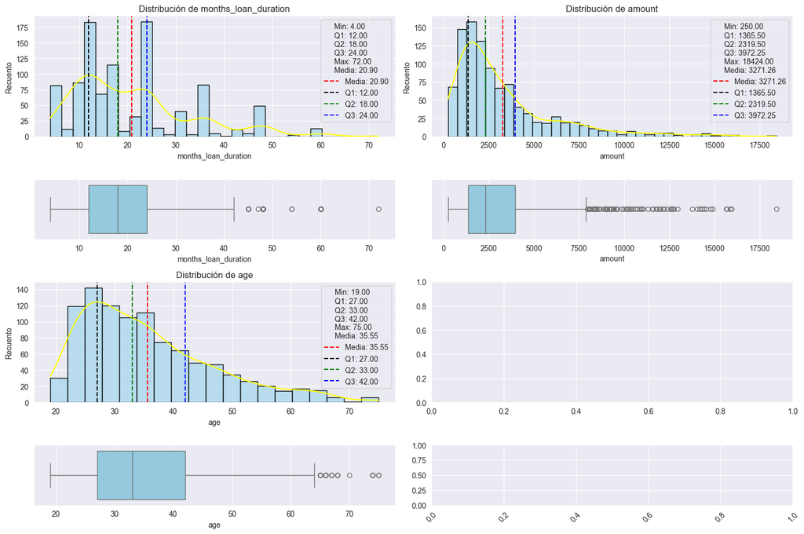

```python
import numpy as np
import math

numerical_columns = df.select_dtypes(include=[np.number]).columns.tolist()
n_vars = len(numerical_columns)
ncols = 2
nrows = math.ceil(n_vars / ncols)  # Redondear hacia arriba

fig, ax = plt.subplots(nrows=nrows*2, ncols=ncols, figsize=(15, nrows * 5), gridspec_kw={'height_ratios': [2, 1] * nrows},
    sharex=False)
#ax.reshape(nrows, ncols)  # Asegurarse de que los ejes están en la forma correcta

ax = ax.reshape(nrows * 2, ncols)

for i, col in enumerate(numerical_columns):

    if col == 'default':
        continue

    col_pos = i % ncols
    row_pos = (i // ncols) * 2
    ax_dist = ax[row_pos, col_pos]
    ax_box = ax[row_pos + 1, col_pos]

    stats = df[col].describe()
    q1 = df[col].quantile(0.25)
    q2 = df[col].quantile(0.50)
    q3 = df[col].quantile(0.75)
    mean = df[col].mean()

    # Histograma
    sns.histplot(df[col], kde=True, ax=ax_dist,
                    color='skyblue', edgecolor='black')
    for line in ax_dist.lines:
        line.set_color("yellow")
    ax_dist.axvline(mean, color='red', linestyle='--', label=f"Media: {mean:.2f}")
    ax_dist.axvline(q1, color='black', linestyle='--', label=f"Q1: {q1:.2f}")
    ax_dist.axvline(q2, color='green', linestyle='--', label=f"Q2: {q2:.2f}")
    ax_dist.axvline(q3, color='blue', linestyle='--', label=f"Q3: {q3:.2f}")

    legend_text = (f"Min: {stats['min']:.2f}\nQ1: {q1:.2f}\nQ2: {q2:.2f}\n"
                    f"Q3: {q3:.2f}\nMax: {stats['max']:.2f}\nMedia: {mean:.2f}")
    ax_dist.legend(title=legend_text, loc='upper right')
    ax_dist.set_ylabel("Recuento")
    ax_dist.set_title(f"Distribución de {col}")

    # 🔹 Boxplot
    sns.boxplot(x=col, data=df, ax=ax_box, color='skyblue', orient='h')
    ax_box.set_yticks([])

plt.xticks(rotation=45)
plt.tight_layout()
plt.show()
```

Observamos que algunas de las clases identificadas como númericas observamos que reflejan categorías codificadas con valores numéricos. Estas características son:

- `installment_rate`
- `residence_history`
- `existing_credits`
- `dependents`

Transformaremos estas columnas a categorías para no confundirlas con numéricas.

A continuación, mostramos la matriz de correlación solamente para las variables numéricas.

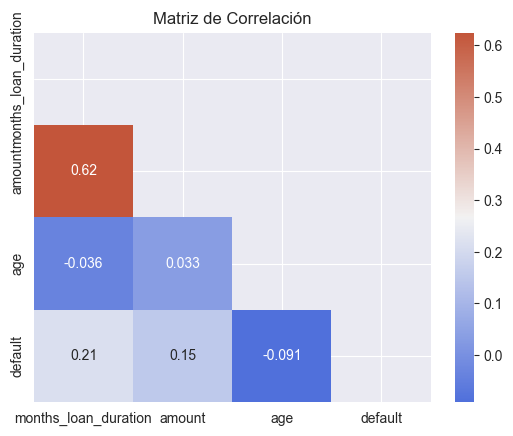

```python
corr = df.select_dtypes(include='number').corr()
mask = np.triu(np.ones_like(corr, dtype=bool))
cmap = sns.diverging_palette(260, 20, as_cmap=True)

sns.heatmap(corr, mask=mask, cmap=cmap, annot=True)
plt.title("Matriz de Correlación")
plt.show()
```

**Resumen de la características numéricas**

`months_loan_duration`

- Observamos que la duración del préstamo suele ser aproximadamnente entre 12 y 24 meses, con una media de 20 meses.
- Encontramos algunos valores atípicos en la duración del préstamo, puede que se traten de casos de préstamos a largo plazo o con determinadas condiciones. Habría que investigar más a fondo.
- La relación con la variable objetivo `default` es de 0.21 siendo la relación positiva más alta entre las variables numéricas. Esto indica que el aumento de la duración del préstamo está relacionado con un aumento en la probabilidad de ser un mal pagador.

**Conclusiones de las características numéricas**

- Las variables de duración del préstamo y cantidad del préstamo muestran una relación positiva con la probabilidad de impago, siendo la duración del préstamo el factor más relevante. Los préstamos más largos y de mayor cantidad parecen estar asociados con un mayor riesgo de ser malos pagadores. La edad no tiene una relación significativa con el comportamiento de pago, lo que sugiere que no es un factor crítico para predecir si alguien será un mal pagador.

#### Características categóricas

Realizaremos una observación mostrando la distribución total de la variables categóricas además de su proporción en función de la variable objetivo.

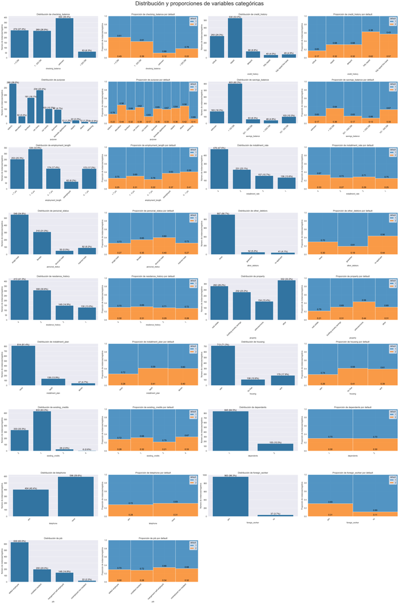

```python
categorical_columns = df.select_dtypes(include=['object']).columns.tolist()
n_vars = len(categorical_columns)
ncols = 4
nrows = (n_vars + 1) // 2  # Redondear hacia arriba

fig, ax = plt.subplots(nrows=nrows, ncols=ncols, figsize=(30, nrows * 5))
ax.reshape(nrows, ncols)  # Asegurarse de

for i, col in enumerate(categorical_columns):
    if col == 'default':
        continue
    row = i // 2
    col_offset = (i % 2) * 2
    sns.countplot(df, x=col, ax=ax[row, col_offset])
    ax[row, col_offset].set_title(f'Distribución de {col}')
    ax[row, col_offset].set_xlabel(col)
    ax[row, col_offset].set_ylabel("Número de instancias/registros")
    for label in ax[row, col_offset + 1].get_xticklabels():
        label.set_rotation(45)
        label.set_horizontalalignment('right')

    add_number_and_percentage_annotation(ax[row, col_offset], df.shape[0])

    # Gráfico de proporción para cada columna categórica
    sns.histplot(df, x=col, hue="default", multiple="fill", palette="tab10", ax=ax[row, col_offset+1], stat="proportion")
    add_number_and_percentage_annotation(ax[row, col_offset+1], df.shape[0], type='proportion')
    ax[row, col_offset+1].set_title(f'Proporción de {col} por default')
    ax[row, col_offset+1].set_xlabel(col)
    ax[row, col_offset+1].set_ylabel("Proporción de instancias/registros")
    for label in ax[row, col_offset].get_xticklabels():
        label.set_rotation(45)
        label.set_horizontalalignment('right')


# Total de subplots usados (2 por cada variable)
used_axes = len(categorical_columns) * 2

# Aplanamos los ejes para recorrer fácilmente
flat_ax = ax.flatten()

# Eliminamos los subplots sobrantes
for i in range(used_axes, len(flat_ax)):
    fig.delaxes(flat_ax[i])

fig.suptitle('Distribución y proporciones de variables categóricas', fontsize=30, y=1.005)
plt.tight_layout()
plt.show()
```

**Resumen de la características categóricas**

`checking_balance`

- La mayoría de las personas presentan un estado de cuenta corriente `unknown` (39,4%).
- Los siguientes grandes grupos de personas son aquellos con estados de cuenta corriente `< 0 DM` y `1-200 DM` (27,4% y 26,9% respectivamente).
- El grupo minoritario es el de personas con estado de cuenta corriente `> 200 DM` (6,3%).
- Observamos que las personas con estado de cuenta corriente `unknown` tienen una proporción de buenos pagadores del 88%.
- La proporción de buenos pagadores para las personas con estado de cuenta corriente `< 0 DM` es del 51% y para aquellos con estado de cuenta corriente `1-200 DM` es del 61%.
- La proporción de buenos pagadores para las personas con estado de cuenta corriente `> 200 DM` es del 78%.
- Podemos concluir que el estado de cuenta corriente `unknown` y `> 200 DM` son los que tienen una mayor proporción de buenos pagadores, mientras que el estado de cuenta corriente `< 0 DM` es el que tiene la menor proporción de buenos pagadores.

`credit_history`

- La mayoría de personas presentan un historial de crédito `repaid` (53%).
- Aquellas personas con historial de crédito `critical` (29,3%) tienen una proporción de buenos pagadores del 83%.
- Las personas con historial de crédito `repaid` (53%) y `delayed` (8,8%) tienen una proporción de buenos pagadores del 68%.
- Las otras dos categorías `fully repaid` y `fully repaid this bank` tienen muchos menos resultados y una proporción de buenos pagadores por debajo del 50%
- Es posible que las personas con historial de crédito `critical` sean aquellas que han tenido problemas de pago en el pasado, pero que han logrado recuperarse y pagar sus deudas. Esto podría indicar que estas personas son más responsables con sus pagos en el presente.
- Que la proporción sea similar tanto en `repaid` como en `delayed` puede no ser del todo correcta debido a la gran diferencia de datos entre ambas categorías.

`purpose`

- Por norma general en todas las categorías encontramos buenos pagadores. En `education` la proporción es más baja (56%) y en `car (used)` es la más alta (83%).
- La gran mayoría de personas solicitan un préstamo para `radio/tv` (28%), `car (new)` (23,4%) y `furniture` (18,1%) sumando un total del 69,5% de los datos.

`savings_balance`

- La mayoría de personas presentan un saldo de ahorros del tipo `< 100 DM` (60,3%). Se destaca que la proporción de buenos pagadores es del 64%.
- La categoría `101-500 DM` tiene una proporción de buenos pagadores del 67% y representa el 10,3% de los datos.
- Para el resto de categorías, el volumen de datos es menor y la proporción de buenos pagadores supera el 80% en cada categoría.

`employment_length`

- La distribución de personsa es bastante regular, salvo porque la categoría `1 - 4 yrs` es la que más datos tiene (33,9%) y la categoría `unemployed` es la que menos (6,2%).
- La proporción de buenos pagadores es del 64% para la categoría `unemployed` y del 70% para la categoría `1 - 4 yrs`.
- Observamos una proporción de buenos pagadores cercana o superor al 70% para aquellas personas que han trabajado por más de 4 años. Desempleados y aquellos que han trabajado menos de 4 años son los que tienen una menor proporción de buenos pagadores, cercana al 60%.

`installment_rate`

- Se observa que las personas con una tasa de pago más baja (valor 1) tienen la mayor proporción de buenos pagadores (75%), mientras que aquellas con una tasa de pago más alta (valor 4) tienen la menor proporción (67%).
- Probablemente una tasa de pago más baja podría estar asociada con un comportamiento de pago más responsable, lo cual podría indicar una menor presión económica para cumplir con los pagos. Sin embargo, el número de registros es mayor en las categorías con tasas de pago más altas, lo que podría afectar la representatividad de los datos en estas categorías.

`residence_history`

- Se observa que la proporción de buenos pagadores es bastante similar en todas las categorías, con una ligera tendencia al alza a medida que disminuye el valor de la categoría (de 69% en el valor 2 a 72% en el valor 1).
- Aunque la variación no es significativa, las personas con una historia de residencia más estable (valor 1) tienden a tener una mayor proporción de buenos pagadores.
- La diferencia entre las categorías no es lo suficientemente grande como para ser un factor determinante por sí sola.

`property`

- La distribución de los datos es más o menos similar en todas las categorías.
- La categoría `real estate` es la que mejor proporción de buenos pagadores tiene (79%).
- Aquellos que tienen `unknown/none` son los que menor proporción de buenos pagadores tienen (56%).

`installment_plan`

- La mayoría de personas no tienen un plan de pago (81,4%).
- Las personas que no tienen un plan de pago tienen una mejor proporción de buenos pagadores que aquellos que si lo tienen (72% vs aprox 60%).

`existing_credits`

- Se observa que, aunque el valor 1 tiene la mayor cantidad de registros, su proporción de buenos pagadores (68%) es ligeramente inferior a la del valor 2 (72%).
- El valor 3, aunque tiene pocos registros, muestra la mayor proporción de buenos pagadores (79%). La categoría con menos registros, el valor 4, tiene una proporción de buenos pagadores del 67%, que es la más baja.
- En general, un número mayor de créditos existentes no parece estar directamente relacionado con un aumento en la probabilidad de ser un buen pagador, aunque la pequeña cantidad de datos en las categorías con valores 3 y 4 puede influir en los resultados.

`dependents`

- Se observa que tanto las personas con 1 dependiente como aquellas con 2 dependientes tienen una proporción similar de buenos pagadores (70%). La distribución de registros es significativamente mayor para las personas con 1 dependiente, lo que podría hacer que esta categoría sea más representativa en comparación con la categoría de 2 dependientes. Sin embargo, no parece haber una diferencia notable en la proporción de buenos pagadores entre ambas categorías.

`telephone`

- Solamente el 40,4% de las personas tienen el teléfono registrado a su nombre
- No proporción de buenos pagadores es bastante similar independientemente de si tienen o no el teléfono registrado a su nombre (aprox 70%).

`foreign_worker`

- La mayoría de personas son trabajadores extranjeros (96,3%).
- La proporción de buenos pagadores es del 89% para aquellos trabajadores que no son extranjeros. Es posible que debido al volumen reducido de datos (37/1000) la proporción de buenos pagadores sea tan alta, sería interesante obtener más datos para comprobar si esta proporción se mantiene.
- Por norma general los trabajadores extranjeros son buenos pagadores (69%).

`job`

- Observamos que la mayoría de personas son trabajadores de tipo `skilled employee` (63%).
- La proporción de buenos pagadores ronda el 70% para todas las categorías. La categoría de `management self-employed` es la que tiene la peor proporción de buenos pagadores (66%). Lo cual es sorprendente porque se tratan de altos puestos directivos en organizaciones. Sería interesante realizar un análisis más en profundidad para estudiar este grupo.

**Conclusiones generales características categóricas:**

Las personas con mayor estabilidad financiera y laboral, como las que tienen cuentas corrientes estables, una historia de crédito positiva, y propiedad inmobiliaria, son más propensas a ser buenos pagadores. Factores como el empleo prolongado y la vivienda propia también juegan un papel importante en minimizar el riesgo de impago. Sin embargo, ciertas categorías menos representadas, como los trabajadores no extranjeros o los directivos autónomos, podrían tener perfiles que requieren mayor exploración.

El desequilibrio de la variable objetivo (70% buenos pagadores y 30% malos pagadores) sugiere que los modelos predictivos deben estar cuidadosamente ajustados para no favorecer excesivamente a los buenos pagadores.

### Preparación de los datos

[ inicio del documento ]

#### Normalización y escalado

Normalizamos y escalamos las variables numéricas utilizando el objeto `StandardScaler` de `sklearn`. Esta técnica es importante para asegurar que todas las variables tengan la misma escala y evitar que algunas dominen el análisis a partir de la siguiente fórmula:

$$ z = \frac{x - \mu}{\sigma} $$

La normalización y escalado se realiza de la siguiente manera:

```python
from sklearn.preprocessing import StandardScaler

numerical_columns = X.select_dtypes(include='number').columns.tolist()

scaler = StandardScaler()
X[numerical_columns] = scaler.fit_transform(X[numerical_columns])
X[numerical_columns].describe()
```

|  | months_loan_duration | amount | age |
| --- | --- | --- | --- |
| count | 1.000000e+03 | 1.000000e+03 | 1.000000e+03 |
| mean | 1.136868e-16 | 6.661338e-17 | 5.329071e-17 |
| std | 1.000500e+00 | 1.000500e+00 | 1.000500e+00 |
| min | -1.402415e+00 | -1.070865e+00 | -1.455261e+00 |
| 25% | -7.386675e-01 | -6.754833e-01 | -7.516417e-01 |
| 50% | -2.408572e-01 | -3.373443e-01 | -2.239269e-01 |
| 75% | 2.569531e-01 | 2.484620e-01 | 5.676451e-01 |
| max | 4.239436e+00 | 5.370789e+00 | 3.470076e+00 |

#### Codificación de variables categóricas

Aplicaremos `Label Encoding` a las variables categóricas para convertirlas en variables numéricas. No haremos uso de `One Hot Encoding` ya que el número de categorías es elevado y podría generar un dataset muy grande. La codificación se realiza de la siguiente manera:

```python
from sklearn.preprocessing import LabelEncoder

categorical_columns = X.select_dtypes(include='object').columns.tolist()

le = LabelEncoder()
for col in categorical_columns:
    X[col] = le.fit_transform(X[col])
X.head()
```

|  | checking_balance | months_loan_duration | credit_history | purpose | amount | savings_balance | employment_length | installment_rate | personal_status | other_debtors | residence_history | property | age | installment_plan | housing | existing_credits | dependents | telephone | foreign_worker | job |
| --- | --- | --- | --- | --- | --- | --- | --- | --- | --- | --- | --- | --- | --- | --- | --- | --- | --- | --- | --- | --- |
| 0 | 1 | -1.236478 | 0 | 7 | -0.745131 | 4 | 3 | 3 | 3 | 2 | 3 | 2 | 2.766456 | 1 | 1 | 1 | 0 | 1 | 1 | 1 |
| 1 | 0 | 2.248194 | 4 | 7 | 0.949817 | 2 | 1 | 1 | 1 | 2 | 1 | 2 | -1.191404 | 1 | 1 | 0 | 0 | 0 | 1 | 1 |
| 2 | 3 | -0.738668 | 0 | 4 | -0.416562 | 2 | 2 | 1 | 3 | 2 | 2 | 2 | 1.183312 | 1 | 1 | 0 | 1 | 0 | 1 | 3 |
| 3 | 1 | 1.750384 | 4 | 5 | 1.634247 | 2 | 2 | 1 | 3 | 1 | 3 | 0 | 0.831502 | 1 | 0 | 0 | 1 | 0 | 1 | 1 |
| 4 | 1 | 0.256953 | 1 | 1 | 0.566664 | 2 | 1 | 2 | 3 | 2 | 3 | 3 | 1.535122 | 1 | 0 | 1 | 1 | 0 | 1 | 1 |

Además como nuestra variable dependiente tambien es categórica haremos uso de `LabelEncoder` para codificar la variable dependiente `y` como binaria (0, 1). La codificación se realiza de la siguiente manera:

```python
from sklearn.preprocessing import LabelEncoder

le = LabelEncoder()
y = le.fit_transform(y).flatten()
y[:10]
```

```
array([0, 1, 0, 0, 1, 0, 0, 0, 0, 1])
```

### Matriz de correlación Global

Observamos la matriz de correlación global para comprobar si existen variables altamente correlacionadas entre sí.

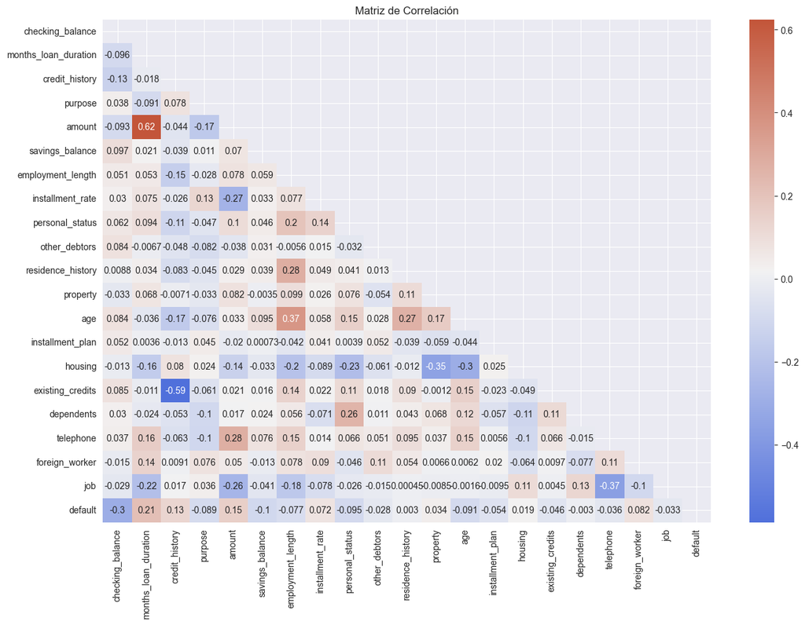

```python
df = X.copy()
df['default'] = y

fig, ax = plt.subplots(figsize=(15, 10))
corr = df.select_dtypes(include='number').corr()
mask = np.triu(np.ones_like(corr, dtype=bool))
cmap = sns.diverging_palette(260, 20, as_cmap=True)

sns.heatmap(corr, mask=mask, cmap=cmap, annot=True, ax=ax)
plt.title("Matriz de Correlación")
plt.show()
```

**Conclusiones de la matriz de correlación global**

- Aunque algunas variables presentan relaciones moderadas o fuertes entre ellas, sólo unas pocas muestran correlaciones relevantes con la variable objetivo `default`.
- Esto indica que el riesgo de impago está influenciado principalmente por factores financieros inmediatos (saldo, duración y monto del préstamo) y que otros aspectos personales o históricos aportan menos peso directo en la predicción del incumplimiento.

## Árbol de decisión

[ inicio del documento ]

Aplicaremos un árbol de decisión a nuestro dataset haciendo uso del objeto `DecisionTreeClassifier` de `sklearn`. Este algoritmo es útil para la clasificación y regresión, y se basa en la creación de un modelo en forma de árbol que toma decisiones basadas en las características de los datos.

Separaremos la variable dependiente `y` de las variables independientes `X` y dividiremos el dataset en un conjunto de entrenamiento y otro de prueba. Utilizaremos el 80% de los datos para el entrenamiento y el 20% para la prueba.

```python
X, y = df.drop(columns=["default"]), df["default"]
print(f"X: {X.shape}, y: {y.shape}")
```

```
X: (1000, 20), y: (1000,)
```

```python
from sklearn.model_selection import train_test_split

X_train, X_test, y_train, y_test = train_test_split(X, y, test_size=0.2, random_state=42, stratify=y)
print(f"X_train: {X_train.shape}, y_train: {y_train.shape}")
```

```
X_train: (800, 20), y_train: (800,)
```

Una vez aplicado el árbol de decisión, siempre es importante obtener una estimación del error. Para ello, utilizaremos distintas métricas de evaluación combinandolas con KFold Cross Validation. Estas métricas son:

- **Accuracy**: Proporción de predicciones correctas sobre el total de predicciones.
- **Precision**: Proporción de verdaderos positivos sobre el total de positivos predichos.
- **Recall**: Proporción de verdaderos positivos sobre el total de positivos reales.
- **F1 Score**: Media armónica entre precisión y recall.
- **ROC AUC**: Área bajo la curva ROC, que mide la capacidad del modelo para distinguir entre clases.
- **Balanced Accuracy**: Promedio de la precisión en cada clase, útil para conjuntos de datos desbalanceados.

```python
from sklearn.tree import DecisionTreeClassifier
from sklearn.tree import plot_tree
from sklearn.model_selection import cross_validate, KFold

clf = DecisionTreeClassifier(random_state=42) # Limitado a 4 para mejorar la visualización

kf = KFold(n_splits=5, shuffle=True, random_state=42)

scoring = ['balanced_accuracy', 'f1', 'roc_auc', 'precision', 'recall', 'accuracy']

results = cross_validate(clf, X_train, y_train, cv=kf, scoring=scoring, return_train_score=False)
for metric in scoring:
    print(f"{metric}: {results[f'test_{metric}'].mean():.4f} ± {results[f'test_{metric}'].std():.4f}")
```

```
balanced_accuracy: 0.6194 ± 0.0225
f1: 0.4664 ± 0.0436
roc_auc: 0.6194 ± 0.0225
precision: 0.4663 ± 0.0633
recall: 0.4687 ± 0.0313
accuracy: 0.6800 ± 0.0195
```

**Resumen de las métricas de evaluación**

- La métrica de `balanced_accuracy` indica que el modelo tiene un desempeño moderadamente equilibrado entre ambas clases, superando claramente el azar (0.5). La desviación baja sugiere estabilidad consistente a lo largo de las particiones del conjunto de datos.
- El valor de `f1` (F1-score) refleja un equilibrio razonable entre precisión y recall, mostrando que el modelo logra un compromiso aceptable entre evitar falsos positivos y falsos negativos. Este resultado indica una capacidad moderada para identificar correctamente los casos positivos.
- El área bajo la curva ROC (`roc_auc`) está por encima de 0.6, lo que significa que el modelo tiene cierta capacidad para discriminar entre clases positivas y negativas, aunque no es muy alto. La baja desviación refleja una evaluación consistente.
- Según los resultados de `precision`, aproximadamente el 46,6% de las predicciones positivas son correctas, lo que implica que hay un número moderado de falsos positivos.
- El `recall` muestra que el modelo es capaz de identificar cerca del 47% de los casos positivos reales, reflejando una capacidad moderada para detectar la clase de interés.
- La exactitud (`accuracy`) global del modelo es del 68%, lo que indica que en general, el modelo clasifica correctamente la mayoría de los casos, aunque en problemas con clases desbalanceadas esta métrica puede ser menos representativa.

## Reglas del árbol de decisión

[ inicio del documento ]

Mostraremos a continuación el árbol de decisión obtenido.

Nota: Realizaremos comentarios sobre el árbol de decisión limitando su profundidad a 3 niveles. Esto se hace para facilitar la visualización y comprensión del árbol. Posteriormente mostraremos el árbol completo.

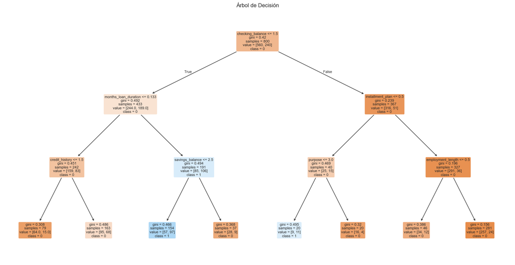

```python
clf_limited = DecisionTreeClassifier(random_state=42, max_depth=3) # Limitado a 3 para mejorar la visualización

clf_limited.fit(X_train, y_train)
plt.figure(figsize=(20, 10))
plot_tree(clf_limited, filled=True, feature_names=X_train.columns, class_names=[str(cls) for cls in clf_limited.classes_], rounded=True, fontsize=8)
plt.title("Árbol de Decisión")
plt.show()
```

**Análisis sobre el árbol de decisión**

1. Nodo Raíz
   - **Condición:** `checking_balance <= 1.5`
   - **Muestras:** 800
   - **Gini:** 0.42 (impureza moderada)
   - **Distribución de clases:** 560 de clase 0, 240 de clase 1
   - **Interpretación:** El primer criterio para dividir los datos es el saldo en la cuenta corriente (`checking_balance`). Si el saldo es menor o igual a 1.5, se sigue por la rama izquierda; de lo contrario, por la derecha.
2. Rama Izquierda (True: `checking_balance <= 1.5`)
   - Nodo: `months_loan_duration <= 0.133`
     - **Muestras:** 433
     - **Gini:** 0.492 (alta impureza)
     - **Distribución:** 244 clase 0, 189 clase 1
     - **Interpretación:**  
       Se evalúa la duración del préstamo en meses. Umbral bajo, indica préstamos cortos.
   1. Rama Izquierda: `credit_history <= 1.5`
      - **Muestras:** 242
      - **Gini:** 0.451 (impureza moderada)
      - **Distribución:** 159 clase 0, 83 clase 1
      - **Subnodos:**
        - Nodo con 79 muestras, Gini=0.308, mayoría clase 0
        - Nodo con 163 muestras, Gini=0.486, mayoría clase 0
   2. Rama Derecha: `savings_balance <= 2.5`
      - **Muestras:** 191
      - **Gini:** 0.494 (alta impureza)
      - **Distribución:** 85 clase 0, 106 clase 1
      - **Subnodos:**
        - Nodo con 154 muestras, Gini=0.466, clase 1 dominante
        - Nodo con 37 muestras, Gini=0.368, clase 0 dominante
3. Rama Derecha (False: `checking_balance > 1.5`)
   - Nodo: `installment_plan <= 0.5`
     - **Muestras:** 367
     - **Gini:** 0.239 (baja impureza)
     - **Distribución:** 316 clase 0, 51 clase 1
   1. Rama Izquierda: `purpose <= 3.0`
      - **Muestras:** 40
      - **Gini:** 0.469 (impureza moderada)
      - **Distribución:** 25 clase 0, 15 clase 1
      - **Subnodos:**
        - Nodo con 20 muestras, Gini=0.495, clase 1 dominante
        - Nodo con 20 muestras, Gini=0.32, clase 0 dominante
   2. Rama Derecha: `employment_length <= 0.5`
      - **Muestras:** 327
      - **Gini:** 0.196 (baja impureza)
      - **Distribución:** 291 clase 0, 36 clase 1
      - **Subnodos:**
        - Nodo con 46 muestras, Gini=0.386, clase 0 dominante
        - Nodo con 281 muestras, Gini=0.156, clase 0 dominante

A continuación, mostraremos el árbol de decisión completo. Este árbol es más complejo y puede ser más difícil de interpretar, pero proporciona una visión más completa de cómo se toman las decisiones en el modelo.

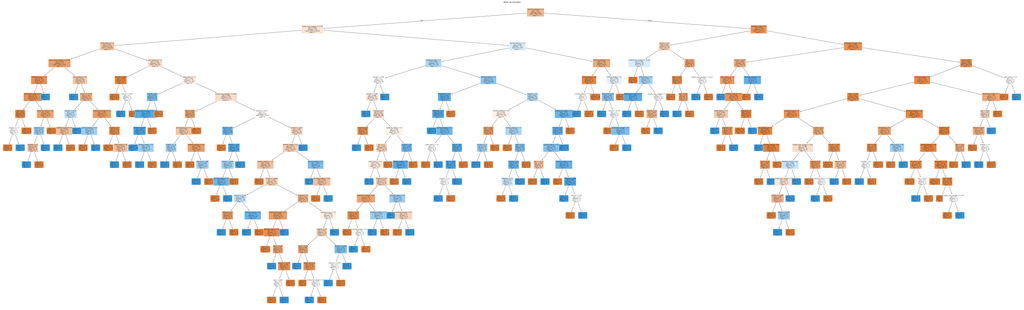

```python
clf.fit(X_train, y_train)
plt.figure(figsize=(100, 30))
plot_tree(clf, filled=True, feature_names=X_train.columns, class_names=[str(cls) for cls in clf.classes_], rounded=True, fontsize=8)
plt.title("Árbol de Decisión")
plt.show()
```

## Bondad de ajuste

[ inicio del documento ]

Realizaremos una predicción con el modelo obtenido utilizando el conjunto de test que hemos separado anteriormente. Para ello, utilizaremos el método `predict` y `predict_proba` del objeto `DecisionTreeClassifier`. Esto nos permitirá obtener tanto las predicciones como las probabilidades de cada clase para su posterior medición con las métricas utilizadas anteriomente. Adicionalmente observaremos la matriz de confusión para comprobar el número de aciertos y errores del modelo.

```
Accuracy: 0.7000
Balanced Accuracy: 0.6524
F1 Score: 0.5161
ROC AUC: 0.6524
Precision: 0.5000
Recall: 0.5333
```

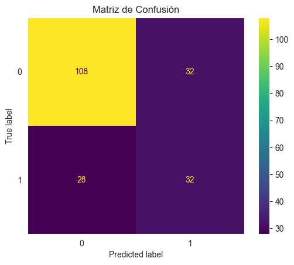

```python
from sklearn.tree import DecisionTreeClassifier
from sklearn.metrics import (
    accuracy_score,
    precision_score,
    recall_score,
    f1_score,
    roc_auc_score,
    balanced_accuracy_score,
    confusion_matrix,
    ConfusionMatrixDisplay,
)

clf = DecisionTreeClassifier(random_state=42)
clf.fit(X_train, y_train)

y_pred = clf.predict(X_test)
y_prob = clf.predict_proba(X_test)[:, 1]

accuracy = accuracy_score(y_test, y_pred)
balanced_acc = balanced_accuracy_score(y_test, y_pred)
f1 = f1_score(y_test, y_pred)
roc_auc = roc_auc_score(y_test, y_prob)
precision = precision_score(y_test, y_pred)
recall = recall_score(y_test, y_pred)

print(f"Accuracy: {accuracy:.4f}")
print(f"Balanced Accuracy: {balanced_acc:.4f}")
print(f"F1 Score: {f1:.4f}")
print(f"ROC AUC: {roc_auc:.4f}")
print(f"Precision: {precision:.4f}")
print(f"Recall: {recall:.4f}")

cm = confusion_matrix(y_test, y_pred)
disp = ConfusionMatrixDisplay(confusion_matrix=cm, display_labels=clf.classes_)
disp.plot()
plt.title("Matriz de Confusión")
plt.grid(False)
plt.show()
```

**Resumen de las métricas de evaluación con datos de test**

- **Accuracy (0.7000):** El modelo clasifica correctamente el 70% de todas las muestras, lo que indica un desempeño global razonable.
- **Balanced Accuracy (0.6524):** Esta métrica refleja un desempeño equilibrado entre las dos clases, con un valor moderado por encima del azar (0.5), lo que indica que el modelo no está sesgado hacia ninguna clase.
- **F1 Score (0.5161):** Muestra un balance aceptable entre precisión y recall, reflejando que el modelo identifica con cierta efectividad la clase positiva sin generar excesivos falsos positivos o negativos.
- **ROC AUC (0.6524):** Indica una capacidad moderada para discriminar entre clases positivas y negativas. El modelo es mejor que un clasificador aleatorio, pero aún puede mejorar.
- **Precision (0.5000):** De todas las predicciones positivas, el 50% son correctas. Esto significa que hay un número considerable de falsos positivos.
- **Recall (0.5333):** El modelo detecta aproximadamente el 53% de los casos positivos reales, lo que indica una capacidad moderada para identificar la clase positiva.

## Árboles de decisión complementarios

[ inicio del documento ]

Dentro de los árboles de decisión podemos encontrar diferentes algoritmos de tipo ensemble. Estos algoritmos son capaces de combinar las predicciones de varios estimadores de base construidos con un algoritmo de aprendizaje dado con el fin de mejorar la generalizabilidad / robustez con respecto a un único estimador.

Los dos algoritmos más utilizados son: Árboles de gradiente creciente (Gradient Boosting Trees) y Bosques aleatorios (Random Forests).

Estos modelos de ensemble se pueden aplicar a cualquier algoritmo de aprendizaje más allá de los árboles de decisión utilizando técnicas de bagging, boosting, stacking o voting. En este caso aplicaremos el algoritmo de `Random Forest` y `GradientBoostingClassifier` a nuestro dataset y comprobaremos su rendimiento en comparación con el árbol de decisión simple que hemos utilizado anteriormente.

Comencemos con el algoritmo de `Random Forest`:

### Random Forest

[ inicio del documento ]

Random Forest es un algoritmo de aprendizaje automático de tipo ensemble basado en árboles de decisión. Consiste en construir múltiples árboles de decisión independientes durante el entrenamiento y, para la predicción, combina sus resultados (por mayoría en clasificación o promedio en regresión).

Las principales características de Random Forest son:

- **Robustez:** Reduce el sobreajuste (overfitting) típico de los árboles individuales al promediar los resultados de muchos árboles.
- **Aleatoriedad:** Cada árbol se entrena con una muestra aleatoria del conjunto de datos (bootstrap) y, en cada división, selecciona aleatoriamente un subconjunto de variables.
- **Importancia de variables:** Permite estimar la importancia relativa de cada variable en la predicción.
- **Versatilidad:** Se puede aplicar tanto a problemas de clasificación como de regresión.

```
Accuracy: 0.7900
Balanced Accuracy: 0.6929
F1 Score: 0.5625
ROC AUC: 0.8001
Precision: 0.7500
Recall: 0.4500
```

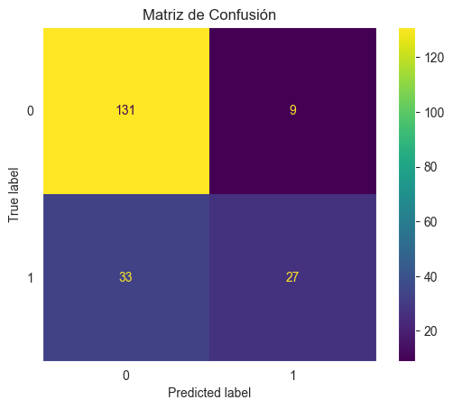

```python
from sklearn.ensemble import RandomForestClassifier
from sklearn.metrics import (
    accuracy_score,
    precision_score,
    recall_score,
    f1_score,
    roc_auc_score,
    balanced_accuracy_score,
    confusion_matrix,
    ConfusionMatrixDisplay,
)

forest = RandomForestClassifier(random_state=42)
forest.fit(X_train, y_train)

y_pred = forest.predict(X_test)
y_prob = forest.predict_proba(X_test)[:, 1]

accuracy = accuracy_score(y_test, y_pred)
balanced_acc = balanced_accuracy_score(y_test, y_pred)
f1 = f1_score(y_test, y_pred)
roc_auc = roc_auc_score(y_test, y_prob)
precision = precision_score(y_test, y_pred)
recall = recall_score(y_test, y_pred)
print(f"Accuracy: {accuracy:.4f}")
print(f"Balanced Accuracy: {balanced_acc:.4f}")
print(f"F1 Score: {f1:.4f}")
print(f"ROC AUC: {roc_auc:.4f}")
print(f"Precision: {precision:.4f}")
print(f"Recall: {recall:.4f}")

cm = confusion_matrix(y_test, y_pred)
disp = ConfusionMatrixDisplay(confusion_matrix=cm, display_labels=forest.classes_)
disp.plot()
plt.title("Matriz de Confusión")
plt.grid(False)
plt.show()
```

### Gradient Boosting

[ inicio del documento ]

GradientBoostingClassifier es un algoritmo de aprendizaje automático de tipo ensemble basado en la técnica de boosting. Su funcionamiento se basa en construir secuencialmente múltiples árboles de decisión débiles (generalmente poco profundos), donde cada nuevo árbol intenta corregir los errores cometidos por el conjunto de árboles anteriores.

Características principales:

- **Aprendizaje secuencial:** Cada árbol se entrena para predecir los residuos (errores) del modelo anterior, mejorando progresivamente la predicción.
- **Reducción del error:** El modelo final es una combinación ponderada de todos los árboles, lo que permite reducir el sesgo y mejorar la precisión.
- **Flexibilidad:** Permite ajustar hiperparámetros como la tasa de aprendizaje, el número de árboles y la profundidad máxima de cada árbol.
- **Importancia de variables:** Ofrece métricas para interpretar la relevancia de cada variable en la predicción.

```
Accuracy: 0.7900
Balanced Accuracy: 0.7119
F1 Score: 0.5962
ROC AUC: 0.7843
Precision: 0.7045
Recall: 0.5167
```

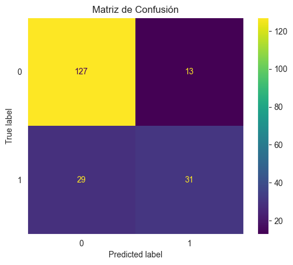

```python
from sklearn.ensemble import GradientBoostingClassifier
from sklearn.metrics import (
    accuracy_score,
    precision_score,
    recall_score,
    f1_score,
    roc_auc_score,
    balanced_accuracy_score,
    confusion_matrix,
    ConfusionMatrixDisplay,
)

gbm = GradientBoostingClassifier(random_state=42)
gbm.fit(X_train, y_train)

y_pred = gbm.predict(X_test)
y_prob = gbm.predict_proba(X_test)[:, 1]

accuracy = accuracy_score(y_test, y_pred)
balanced_acc = balanced_accuracy_score(y_test, y_pred)
f1 = f1_score(y_test, y_pred)
roc_auc = roc_auc_score(y_test, y_prob)
precision = precision_score(y_test, y_pred)
recall = recall_score(y_test, y_pred)
print(f"Accuracy: {accuracy:.4f}")
print(f"Balanced Accuracy: {balanced_acc:.4f}")
print(f"F1 Score: {f1:.4f}")
print(f"ROC AUC: {roc_auc:.4f}")
print(f"Precision: {precision:.4f}")
print(f"Recall: {recall:.4f}")

cm = confusion_matrix(y_test, y_pred)
disp = ConfusionMatrixDisplay(confusion_matrix=cm, display_labels=gbm.classes_)
disp.plot()
plt.title("Matriz de Confusión")
plt.grid(False)
plt.show()
```

### Comparación entre modelos: Árbol de Decisión vs Random Forest vs Gradient Boosting

| Métrica | Árbol de Decisión | Random Forest | Gradient Boosting | Comentario |
| --- | --- | --- | --- | --- |
| **Accuracy** | 0.7000 | 0.7900 | 0.7900 | Random Forest y Gradient Boosting mejoran notablemente la exactitud general respecto al árbol simple. |
| **Balanced Accuracy** | 0.6524 | 0.6929 | 0.7119 | Gradient Boosting muestra el mejor equilibrio entre clases, seguido por Random Forest. |
| **F1 Score** | 0.5161 | 0.5625 | 0.5962 | Gradient Boosting ofrece el mejor balance entre precisión y recall, con Random Forest en segundo lugar. |
| **ROC AUC** | 0.6524 | 0.8001 | 0.7843 | Random Forest presenta la mayor capacidad discriminativa, seguida muy de cerca por Gradient Boosting. |
| **Precision** | 0.5000 | 0.7500 | 0.7045 | Random Forest tiene la mejor precisión, aunque Gradient Boosting también mejora considerablemente respecto al árbol simple. |
| **Recall** | 0.5333 | 0.4500 | 0.5167 | El árbol tiene el mayor recall, pero Random Forest prioriza precisión y Gradient Boosting mantiene un equilibrio moderado. |

**Comparación de Matrices de Confusión**

[output not shown]

**Análisis general**

## Conclusiones Finales

[ inicio del documento ]

**En resumen:**

### Bibliografía

[ inicio del documento ]

- [Statlog (German Credit Data)](https://archive.ics.uci.edu/dataset/144/statlog+german+credit+data)
- [Análisis Univariado con Python](https://www.linkedin.com/pulse/an%C3%A1lisis-univariado-con-python-luis-felipe-castro-calder%C3%B3n/)
- [Árboles de Decisión](https://scikit-learn.org/stable/modules/tree.html)
- [Modelos Ensemble](https://scikit-learn.org/stable/modules/ensemble.html#)
- [Random Forest](https://scikit-learn.org/stable/modules/ensemble.html#random-forests-and-other-randomized-tree-ensembles)
- [Gradient Boosted Trees](https://scikit-learn.org/stable/modules/ensemble.html#gradient-boosted-trees)
- [pandas](https://pandas.pydata.org/)
- [scikit-learn](https://scikit-learn.org/stable/)
- [matplotlib](https://matplotlib.org/)
- [seaborn](https://seaborn.pydata.org/)
- [pandera](https://pandera.readthedocs.io/en/stable/)